# Bagging and random forests

Charlie Stone

27/01/2019

## 0. Setup

Load packages.

```r
library(MASS)
library(tidyverse)
library(tidymodels)
library(caret)
```

```r
library(plotly)
```

### Bagging

Load Boston data.

```r
boston_df <- as_tibble(Boston)

# Summary view of data
boston_df[1:10, ]
```

```
## # A tibble: 10 x 14
##       crim    zn indus  chas   nox    rm   age   dis   rad   tax ptratio
##      <dbl> <dbl> <dbl> <int> <dbl> <dbl> <dbl> <dbl> <int> <dbl>   <dbl>
##  1 0.00632  18    2.31     0 0.538  6.58  65.2  4.09     1   296    15.3
##  2 0.0273    0    7.07     0 0.469  6.42  78.9  4.97     2   242    17.8
##  3 0.0273    0    7.07     0 0.469  7.18  61.1  4.97     2   242    17.8
##  4 0.0324    0    2.18     0 0.458  7.00  45.8  6.06     3   222    18.7
##  5 0.0690    0    2.18     0 0.458  7.15  54.2  6.06     3   222    18.7
##  6 0.0298    0    2.18     0 0.458  6.43  58.7  6.06     3   222    18.7
##  7 0.0883   12.5  7.87     0 0.524  6.01  66.6  5.56     5   311    15.2
##  8 0.145    12.5  7.87     0 0.524  6.17  96.1  5.95     5   311    15.2
##  9 0.211    12.5  7.87     0 0.524  5.63 100    6.08     5   311    15.2
## 10 0.170    12.5  7.87     0 0.524  6.00  85.9  6.59     5   311    15.2
## # … with 3 more variables: black <dbl>, lstat <dbl>, medv <dbl>
```

```r
summary(boston_df)
```

```
##       crim                zn             indus            chas
##  Min.   : 0.00632   Min.   :  0.00   Min.   : 0.46   Min.   :0.00000
##  1st Qu.: 0.08204   1st Qu.:  0.00   1st Qu.: 5.19   1st Qu.:0.00000
##  Median : 0.25651   Median :  0.00   Median : 9.69   Median :0.00000
##  Mean   : 3.61352   Mean   : 11.36   Mean   :11.14   Mean   :0.06917
##  3rd Qu.: 3.67708   3rd Qu.: 12.50   3rd Qu.:18.10   3rd Qu.:0.00000
##  Max.   :88.97620   Max.   :100.00   Max.   :27.74   Max.   :1.00000
##       nox               rm             age              dis
##  Min.   :0.3850   Min.   :3.561   Min.   :  2.90   Min.   : 1.130
##  1st Qu.:0.4490   1st Qu.:5.886   1st Qu.: 45.02   1st Qu.: 2.100
##  Median :0.5380   Median :6.208   Median : 77.50   Median : 3.207
##  Mean   :0.5547   Mean   :6.285   Mean   : 68.57   Mean   : 3.795
##  3rd Qu.:0.6240   3rd Qu.:6.623   3rd Qu.: 94.08   3rd Qu.: 5.188
##  Max.   :0.8710   Max.   :8.780   Max.   :100.00   Max.   :12.127
##       rad              tax           ptratio          black
##  Min.   : 1.000   Min.   :187.0   Min.   :12.60   Min.   :  0.32
##  1st Qu.: 4.000   1st Qu.:279.0   1st Qu.:17.40   1st Qu.:375.38
##  Median : 5.000   Median :330.0   Median :19.05   Median :391.44
##  Mean   : 9.549   Mean   :408.2   Mean   :18.46   Mean   :356.67
##  3rd Qu.:24.000   3rd Qu.:666.0   3rd Qu.:20.20   3rd Qu.:396.23
##  Max.   :24.000   Max.   :711.0   Max.   :22.00   Max.   :396.90
##      lstat            medv
##  Min.   : 1.73   Min.   : 5.00
##  1st Qu.: 6.95   1st Qu.:17.02
##  Median :11.36   Median :21.20
##  Mean   :12.65   Mean   :22.53
##  3rd Qu.:16.95   3rd Qu.:25.00
##  Max.   :37.97   Max.   :50.00
```

Split data into a train and test set.

```r
set.seed(12)
split <- initial_split(boston_df, prop = 0.8)
boston_train <- training(split)
boston_test <- testing(split)

# Specify recipe for pre-processing data and prep train and test datasets using this recipe.
rec <- boston_train %>%
  recipe( ~ .)

prepped <- rec %>%
  prep(retain = TRUE)

train <- prepped %>%
  juice()

test <- prepped %>%
  bake(new_data = boston_test)
```

Fit bagging model with default values for trees = 500 (the number of trees in the ensemble) and min_n (the minimum number of data points in a node for it to be split further).

```r
# Fit tree model to training set
rf_mod <- rand_forest(mode = "regression", mtry = 13) %>%
  set_engine("randomForest") %>%
  fit(medv ~ ., data = train)

rf_mod
```

```
## parsnip model object
##
##
## Call:
##  randomForest(x = as.data.frame(x), y = y, mtry = ~13)
##                Type of random forest: regression
##                      Number of trees: 500
## No. of variables tried at each split: 13
##
##           Mean of squared residuals: 11.92728
##                     % Var explained: 85.9
```

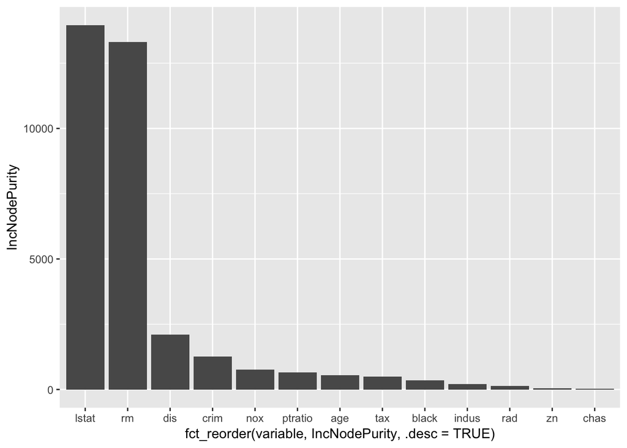

```r
# Variable importance
rf_mod$fit$importance %>%
  as_tibble(rownames = "variable") %>%
  arrange(-IncNodePurity) %>%
  ggplot(aes(fct_reorder(variable, IncNodePurity, .desc = TRUE), IncNodePurity)) +
  geom_bar(stat = "identity")
```

```r
# Evaluate tree performance on test set
test <- test %>%
  bind_cols(predict(rf_mod, new_data = test)) %>%
  rename(bag_pred = ".pred")

# rmse
test %>%
  rmse(truth = medv, estimate = bag_pred)
```

```
## # A tibble: 1 x 3
##   .metric .estimator .estimate
##   <chr>   <chr>          <dbl>
## 1 rmse    standard        2.67
```

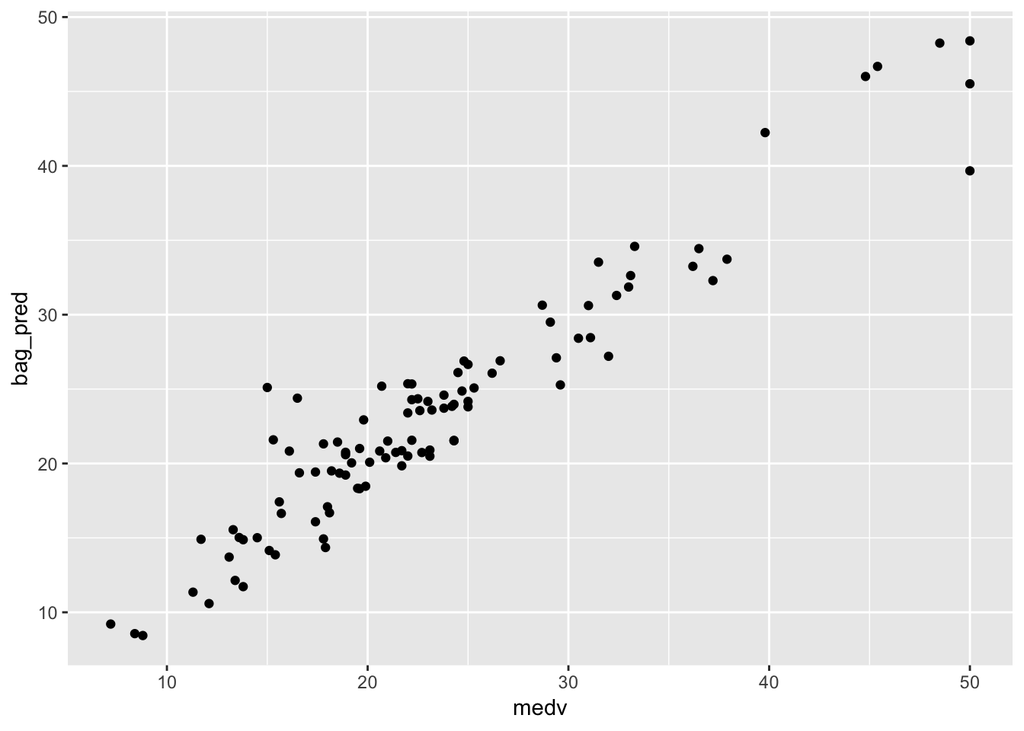

```r
# Scatter plot estimate vs actual
test %>%
  ggplot(aes(medv, bag_pred)) +
  geom_point()
```

Fit bagging models for a grid of different values for trees and min_n. The test rmse does not vary much for different numbers of trees in the ensemble, provided the number of trees is reasoably large - the chart suggests above 300 makes little difference. The test rmse is slightly smaller for smaller values of min_n, the minimum number of data points in a node that are required for the node to be split further. In other words, having more complex trees gives slightly smaller rmse.

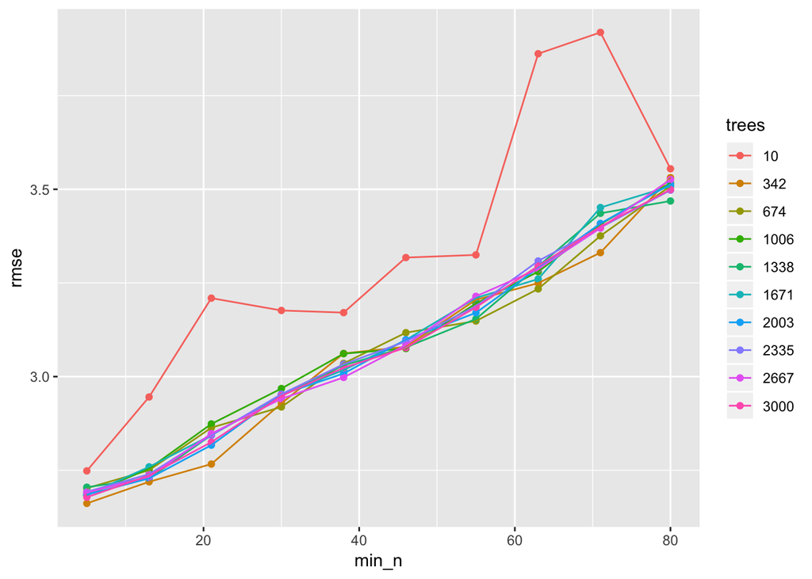

```r
# Setup grid of values to fit models to training data for.
bag_grid <- grid_regular(
  trees %>% range_set(c(10,  3000)),
  min_n %>% range_set(c(5,  80)),
  levels = 10
)

# Helper function to fit model to train data and calculate rmse on test dataset.
fit_rf <- function(rf_mod){
  rf_mod <- rf_mod %>%
  set_engine("randomForest") %>%
  fit(medv ~ ., data = train)

  test %>%
  bind_cols(predict(rf_mod, new_data = test)) %>%
  rmse(truth = medv, estimate = ".pred") %>%
  rename(est = ".estimate") %>%
  dplyr::select(est) %>%
  unlist()
}

# Fit model for each combination of the grid values.
bag_grid <- bag_grid %>%
  mutate(rf_mod = map2(trees, min_n, ~rand_forest(mode = "regression", mtry = 13, trees = .x, min_n = .y)),
         rmse = map_dbl(rf_mod, fit_rf))

# Plot rmse for each value of trees and min_n
bag_grid %>%
  mutate(trees = as_factor(as.character(trees))) %>%
  ggplot(aes(min_n, rmse, colour = trees)) +
  geom_point() +
  geom_line()
```

### Random forests

Now investigate random forests, ie values of mtry other than 13 (the number of variables). Bagging is the case where mtry = 13, the same as the number of variables in the model. A default choice for mtry is p/3 for regression problems. In this case p =13, so 4 is the default. Look at mtry = 2, 4, 8, 10, 13. Use min_n = 20 and trees = 1000.

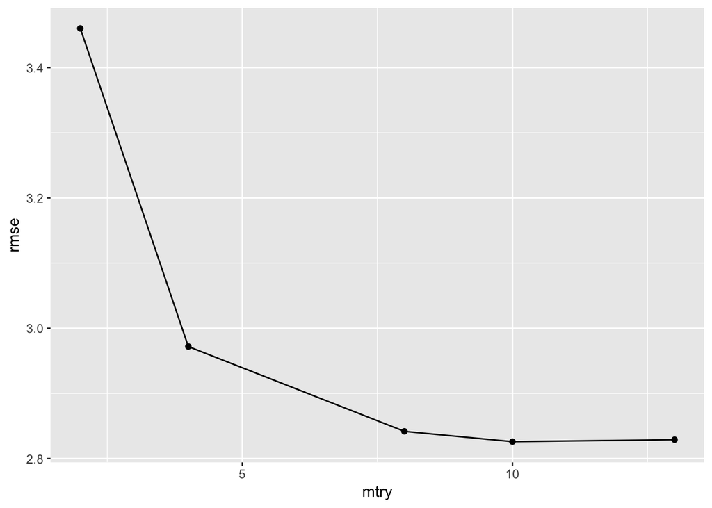

```r
# Setup grid of values to fit models to training data for.
rf_mtry <- tibble("mtry" = c(2, 4, 8, 10, 13))

# Fit random forest model for each value of mtry.
rf_mtry <- rf_mtry %>%
  mutate(rf_mod = purrr::map(mtry, ~rand_forest(mode = "regression", mtry = .x, trees = 1000, min_n = 20)),
         rmse = map_dbl(rf_mod, fit_rf))

# Plot rmse for each value of trees and min_n
rf_mtry %>%
  ggplot(aes(mtry, rmse)) +
  geom_point() +
  geom_line()
```